# R for Insurance

Ricardo Lastra

Junio del 2019

## Agenda

- Welcome!
- Getting Started with R Programming
- R_Basico_1.0
- R_Basico_1.1

### Welcome!

`OBJETIVO:` **Presentación y breve panorama de lo que haremos las próximas semanas**

Recomendación como en todo, dejen a un lado los paradigmas, cosas que han escuchado, leido en diversos medios, y preparense para tener una mente dispuesta.

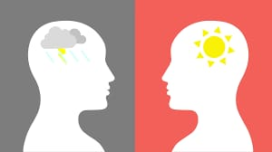

Clear your minds!!!

Hay que ubicarnos en donde estamos en base a lo que hacemos actualmente. No todo lo que hacemos hoy esta mal, pero hay aún mas cosas que aprender.

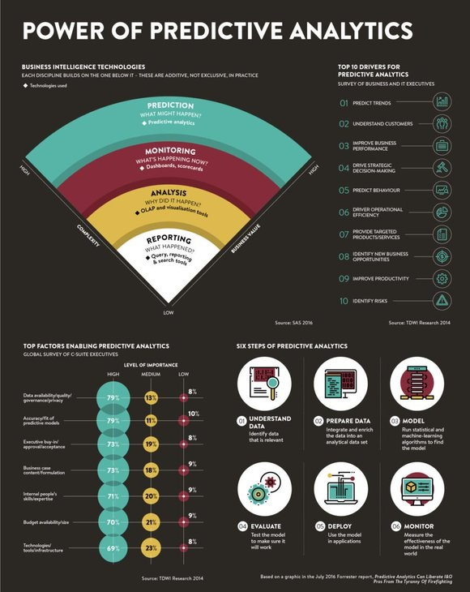

Dónde estamos?

La generación e ingesta de datos hoy es una necesidad, debemos contar con mejores herramientas para el manejo de los mismos. Es muy util en nuestras vidas se consumidores, pero mucho mejor ser generadores y controladores de ellos.

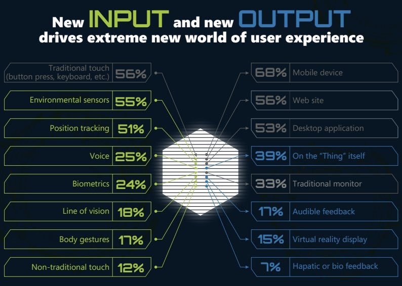

Datos everywhere!

Debemos de empezar por algo, los diferentes lenguajes de programación y otras herramientas denominadas Open Source son un excelente comienzo!!

[figure not shown]

Python y R para empezar

Necesitamos ver el ecosistema, nuestra realidad y tomar la mejor decisión para ver por donde empezamos, todos los lenguajes son utiles, pero no podemos saberlo todo.

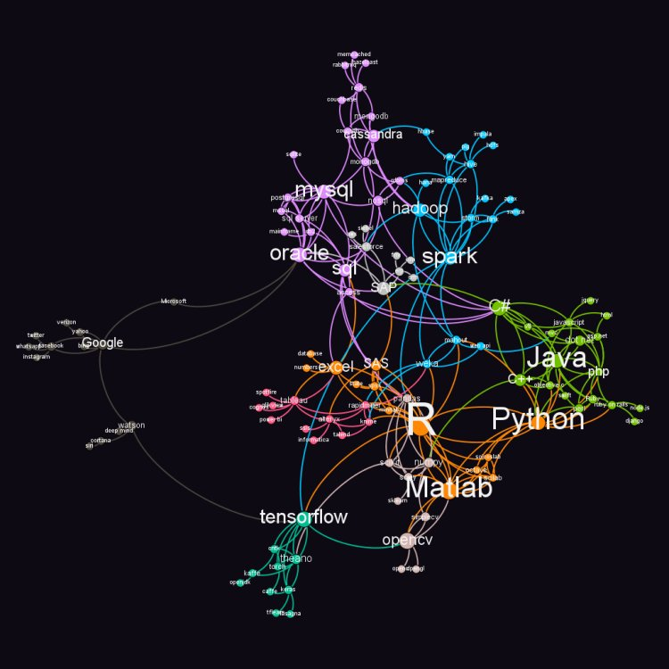

Ecosistema de R

Python y R ya como un mismo lenguaje, es por ello que empezamos con un leguaje poderoso, que ha ganadado el respeto de Python.

[figure not shown]

R y Python una maravilla!

R es un lenguaje muy usado para la enseñanza, cada vez mas universidades lo usan como herramienta para estadística y otras áreas, chequen este articulo. http://r4stats.com/articles/popularity/

Dudas del Open Source, revisen el siguiente Link https://www.gnu.org/licenses/quick-guide-gplv3.html y naveguen.

### Getting Started with R Programming

`OBJETIVO:` **Breve historia de R y contexto**

#### Historia de R

Ross Ihaka and Robert Gentleman desarrollaron `R` como un software *free* cuando impartían clases en la Universidad de Auckland en New Zealand a principios de 1990.

Lo crearon a partir del lenguaje estadístico denominado `S` y para diferenciar su trabajo usaron una sintaxis similar para su propio uso. En 1993 anunciaron su colaboración en las noticias del mailing list de `S`, muchas personas se interesaron y se sumaron a la colaboración. Dicha colaboración sigue en pie en el sitio https://www.r-project.org/

El lanzamiento oficial (1.0.0) fue en Febrero del 2000, para ese entonces ya era parte de la fundación de software libre GNU. Actualmente la última versión (3.6) está disponible desde Abril de este año para más de 30 países.

#### Ventajas y usos de R

Es un software que ayuda a la manipulación de datos, cálculos aritméticos y visualización de gráficos dinámicos.

El código es de fácil escritura y comprensión.

Excelente para el cálculo de matrices, vectores, algoritmos complejos.

Existe una colección muy amplia de herramientas para el análisis de datos, visualización y otros propósitos. `dplyr`, `data.table`, `tidyr` y `ggplot2` algunos de ellos.

Fácil desarrollo de herramientas con buen nivel de interacción como `blogdown` y `xaringan`.

#### Iniciando

Para descargar e instalar `R` en su última versión, deberán utilizar el siguiente link https://cran.r-project.org/bin/windows/base/ donde encontraran la versión para Windows que es el sistema operativo que todos tenemos.

Un lenguaje amigable, fácil de usar y entender, simple y efectivo.

Con `R` se distribuyen algunos paquetes, pero existen muchos más en el sitio CRAN, cubriendo así un amplio espectro de herramientas estadísticas, de cálculo y de visualización que les harán más divertida la vida.

El link con todo el material del curso esta en mi repo personal de Git, tengan cuidado de no aruinarlo, luego hacemos otro curso de Git. https://github.com/ricardolastra/Workshop_Seguros

En los próximos días les hare llegar documentos como estos, los cuales les serán de gran apoyo con cosas básicas, no podemos retener todo en mente, además que no cubriremos muchos comandos, ejemplos y funciones de las paqueterías.

[figure not shown]

Para las siguientes sesiones usaremos una interface muy “Fancy” denominada RStudio, la cual podrán descargar en el siguiente link https://www.rstudio.com/products/rstudio/download/ que los llevara a tener la versión más reciente 1.2.1335

Existen más programas o UI´s muy padres, Anaconda (luego revisan el siguiente link) https://www.anaconda.com/distribution/ tiene excelentes herramientas con Python y aun para R. Sin embargo una de las mejores herramientas con R es RStudio.

No nos perdemos de mucho, échenle un ojo.

[figure not shown]

### R_Basico_1.0

`OBJETIVO:` **Vistazo de Rstudio y primeros comandos**

Recordando…

*R es un lenguaje computacional diseñado para la estadística.*

- Es gratis
- Amplias librerias
- Basto soporte, mailing list, blogs, tutoriales
- De facíl desarrollo
- Desarrolado por estadísticos

Recuerden que cualquier cosa que escriban en R muy probablemente no seran los primeros en intentarlo, hay una gran posibilidad que alguien ya haya escrito algun paquete justo para lo que necesitan.

Hecharemos un vistazo a la parte basica de RStudio que nos permitira entender el funcionamiento del lenguaje, sus alcances, sus aplicaciones y sus ventajas sobre las herramientas actuales que conocemos.

[figure not shown]

Inicien RStudio y abran un R script:

- En Windows click en el boton de Inicio y busquen Rstudio.
- Ya en Rstudio den click en `File -> New File -> R script`
- Guardenlo en su carpeta del curso `File -> Save As -> ruta a su carpeta y nombre del file`

Ahora traten de reproducir las siguientes notas.

Nota. Recuerden el simbolo `#` para comentar su codigo.

**FORMAS DE DECLARAR Ó GUARDAR Ó ALMACENAR Ó MANTENER VARIABLES:**

```r
x = 3
y <- 4
5 -> z
```

**Asi estan almacenadas en el ambiente:**

```r
x
```

```
## [1] 3
```

```r
y
```

```
## [1] 4
```

```r
z
```

```
## [1] 5
```

Nota. Los valores que guardamos pueden ser usados en subsecuentes operaciones, recuerden que lo mas limpio es poner el nombre a la izquierda y los valores a la derecha.

**SOBRESCRIBIR VARIABLES:**

```r
x = 4
y <- 5
6 -> z
```

**Asi estan almacenadas en el ambiente:**

```r
x
```

```
## [1] 4
```

```r
y
```

```
## [1] 5
```

```r
z
```

```
## [1] 6
```

**CALCULOS BASICOS:**

Operadores

```r
#SUMAS
25+25
```

```
## [1] 50
```

```r
x+y
```

```
## [1] 9
```

```r
#MULTIPLICACIONES
35*2
```

```
## [1] 70
```

```r
#DIVISIONES
x/y
```

```
## [1] 0.8
```

```r
#RESTAS
z-x-y
```

```
## [1] -3
```

```r
#Potencias
3^2
```

```
## [1] 9
```

```r
y^x
```

```
## [1] 625
```

**CALCULOS BASICOS**

FORMAS DE **NO** HACER CALCULOS BASICOS, ASI NO ES LA SINTAXIS DE R:

```r
#SUMAS
#=25+25

#MULTIPLICACIONES
#(35)(2)
```

**VECTORES**

```r
#Basicos
x = c(1,4,3,1,3,2,2,2)
x[1]
```

```
## [1] 1
```

```r
x[2]
```

```
## [1] 4
```

```r
x[2:4]
```

```
## [1] 4 3 1
```

```r
x[-1]
```

```
## [1] 4 3 1 3 2 2 2
```

```r
x[-4]
```

```
## [1] 1 4 3 3 2 2 2
```

```r
x[x<=3]
```

```
## [1] 1 3 1 3 2 2 2
```

```r
#Función which (más adelante veremos, for, while, ifelse)
#Devuelve la posición del elemento que pidamos validar.
which(x==1)
```

```
## [1] 1 4
```

```r
#Quizá con el alfabeto es más claro.
which(letters == "g")
```

```
## [1] 7
```

```r
x==1
```

```
## [1]  TRUE FALSE FALSE  TRUE FALSE FALSE FALSE FALSE
```

```r
#Mas complejos con operaciones, guardamos vectores
Cebollas.huacal <- c(12,4,4,6,9,3)
Chiles.caja <- c(5,3,2,2,12,9)
#Multiplicamos vectores
Cebollas.precio <- Cebollas.huacal *200
Chiles.precio <- Chiles.caja *100
#Sumamos vectores
Cebollas.precio + Chiles.precio
```

```
## [1] 2900 1100 1000 1400 3000 1500
```

```r
#Tambien lo podemos hacer asi en 1 sola linea
Cebollas.huacal *200 + Chiles.caja *100
```

```
## [1] 2900 1100 1000 1400 3000 1500
```

**OBJETOS**

```r
objeto <- 3*3
```

**FUNCIONES**

```r
myfun = function(x, y){
  return (x*y)
}
myfun(3,4)
```

```
## [1] 12
```

```r
myfun2 = function(x, n=2){
  return(x^n)
}
myfun2(4)
```

```
## [1] 16
```

```r
myfun2(2, n=3)
```

```
## [1] 8
```

**R LOOP´S**

Sintaxis *WHILE*:

> while (test_expression){ statement }

```r
#FOR LOOP

#WHILE

#IFELSE

#WHICH
```

Nota. Para más detalles consulten los documentos de apoyo del repo de git en el documento `refcard_2.0_operators_others`

### R_Basico_1.1

`OBJETIVO:` **Como cargar datos, paquetes y librerias**

Cargando nuestros datos

R tiene algunas formas de leer archivos, los mas comunes son tablas, archivos planos, archivos con alguna codificacion especifica o estructurada. Aunque no sera el objetivo del curso, leer cadenas de texto, datos sin estructuras definidas o espcificas y archivos sin algun tipo de orden, es algo que tambien se puede hacer en R.

Para leer datos de un archivo, primero deben saber que tipo de archivo es, es decir, su extension. La tabla de abajo muestra una lista de funciones que pueden ser importadas segun el formato del archivo.

| tipo de datos | funcion | paquete |
| --- | --- | --- |
| comma separated (.csv) | `read_csv()` | readr |
| other delimited formats | `read_delim()` | readr |
| R (.Rds) | `read_rds()` | readr |
| Stata (.dta) | `read_dta()` | haven |
| SPSS (.sav) | `read_spss()` | haven |
| SAS (.sas7bdat) | `read_sas()` | haven |
| Excel (.xls, .xlsx) | `read_excel()` | readxl |
| regular delimited files | `fread()` | data.table |

Nota. Mas información ver documento de apoyo `data-import`

Paqueterias de R ó los famosos *packages*

Los paquetes de R pueden ser instalados desde el famoso CRAN, el cual es una red de archivos de alta gama. Para ello deberán usar la función `install.packages`. Cuando instalan un paquete ponen una copia en la computadora de forma local, pero aun no lo hace “usable”, solo esta “disponible”. Para usarlo deberan adjuntar o cargar la funcion de `library`.

Gracias a nuestro amigo Hadley y otros colaboradores, en este curso usaremos para prueba de carga el famoso “the tidyverse”. `Tidyverse` nos brinda grandes herramientas para manipulación basica y avanzada de datos, es muy funcional, facíl e intuitiva.

```r
install.packages("tidyverse")
```

```r
library(tidyverse)
```

Ayuda en R.

Podemos usar la función `help` o el operador al inicio de cada sentencia `?`.

```r
#help(help)
#?str
```